# DSO 522: In-Class Workbook 6

Matteo Sesia

October 1, 2024

# Instructions

Your task is to edit this R Markdown notebook to include your solutions, ensuring that it is well-organized and professional in appearance. Answers must be clear and concise. Start by downloading the Rmd file.

**Collaboration Policy.** You are allowed to discuss this workbook with your classmates and work in groups. Despite group discussions, each student must write and submit their own solutions.

**Assistance Policy.** You may ask for clarifications from the instructor and teaching assistant in class. Do not seek help on these workbooks outside of class, as they are intended to be completed during class time.

**Submission Requirements.** Solutions must be submitted on Brightspace as a PDF writeup. Use the ‘Knit to PDF’ feature in RStudio to prepare your PDF document. Ensure that your PDF document looks like the provided PDF version of the workbook, including all code used to obtain the results in proper code blocks. Make sure your PDF writeup includes *your name* in the title (replace my name with yours).

**Grading Criteria.** This workbook is worth 10 points. To achieve a grade of 10, your writeup must correctly answer all questions, be easy to understand, and be formatted correctly.

**Work Timeline.** You are expected to work on this assignment in class, but you may complete it at home within 24 hours. It is due on October 2, 2024, at 9:30 pm. Late submissions will incur a 50% deduction for any initial delay below 24 hours, and an additional 10% deduction for each additional day.

Remember, you will need to use the `fpp3` package to complete this assignment, as shown in the lecture.

```r
suppressMessages(library(fpp3))
```

**NOTE:** only Problem 1 needs to be completed in order to receive full credit for this assignment. Problems 2 and 3 are optional.

# Problem 1

Half-hourly electricity demand for Victoria, Australia is contained in `vic_elec`. Extract the January 2014 electricity demand, and aggregate this data to daily with daily total demands and maximum temperatures.

```r
jan_vic_elec <- vic_elec |>
   filter(yearmonth(Time) == yearmonth("2014 Jan")) |>
   index_by(Date = as_date(Time)) |>
   summarise(Demand = sum(Demand), Temperature = max(Temperature))
```

1. Plot the data and find the regression model for Demand with temperature as an explanatory variable. Do you see a linear relationship? Can you explain it?
2. Produce a residual plot. Is the model adequate? Are there any outliers or influential observations?
3. Use the model to forecast the electricity demand that you would expect for the next day if the maximum temperature was $15^\circ\text{C}$ and compare it with the forecast if the with maximum temperature was $35^\circ\text{C}$. Do you believe these forecasts?
4. Give prediction intervals for your forecasts.
5. Plot Demand vs Temperature for all of the available data in `vic_elec` aggregated to daily total demand and maximum temperature. What does this say about your model?

# Problem 1 Solutions

### Problem 1a

Plot the data and find the regression model for Demand with temperature as an explanatory variable. Do you see a linear relationship? Can you explain it?

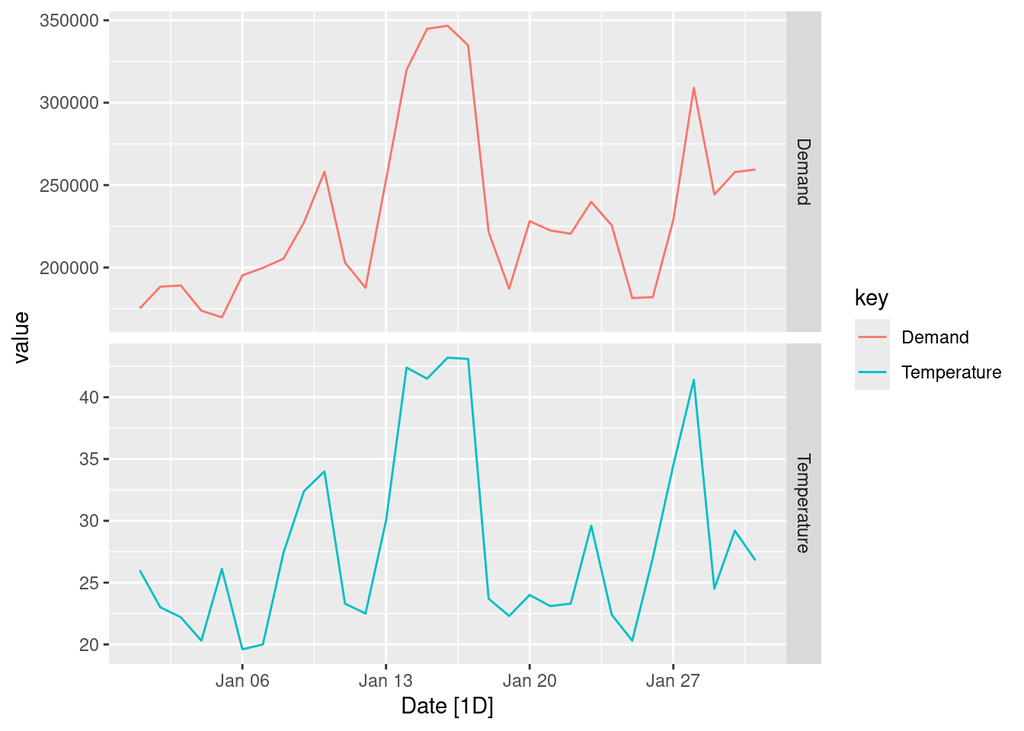

```r
jan_vic_elec <- vic_elec |>
  filter(yearmonth(Time) == yearmonth("2014 Jan")) |>
  index_by(Date = as_date(Time)) |>
  summarise(Demand = sum(Demand), Temperature = max(Temperature))

jan_vic_elec |>
  pivot_longer(2:3, names_to="key", values_to="value")|>
  autoplot(.vars = value) +
  facet_grid(vars(key), scales = "free_y")
```

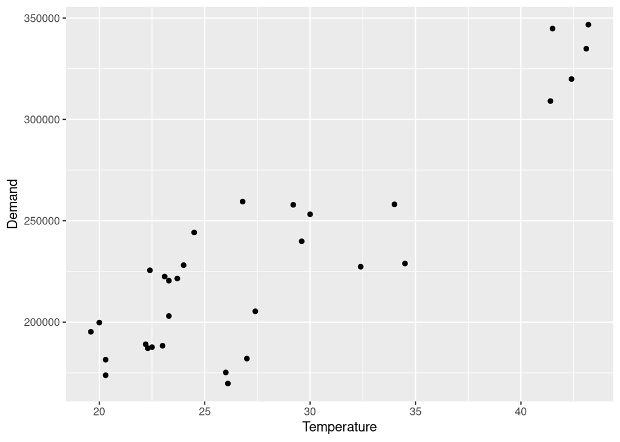

```r
jan_vic_elec |>
  ggplot(aes(x = Temperature, y = Demand)) +
  geom_point()
```

```r
fit <- jan_vic_elec |>
  model(TSLM(Demand ~ Temperature))
fit |> report()
```

```
Series: Demand
Model: TSLM

Residuals:
     Min       1Q   Median       3Q      Max
-49978.2 -10218.9   -121.3  18533.2  35440.6

Coefficients:
            Estimate Std. Error t value Pr(>|t|)
(Intercept)  59083.9    17424.8   3.391  0.00203 **
Temperature   6154.3      601.3  10.235 3.89e-11 ***
---
Signif. codes:  0 '***' 0.001 '**' 0.01 '*' 0.05 '.' 0.1 ' ' 1

Residual standard error: 24540 on 29 degrees of freedom
Multiple R-squared: 0.7832, Adjusted R-squared: 0.7757
F-statistic: 104.7 on 1 and 29 DF, p-value: 3.8897e-11
```

It is clear that a positive relationship exists for this data. It is largely driven by days with high temperatures, that is resulting in more electricity being demanded (presumably to keep things cool).

### Problem 1b

Produce a residual plot. Is the model adequate? Are there any outliers or influential observations?

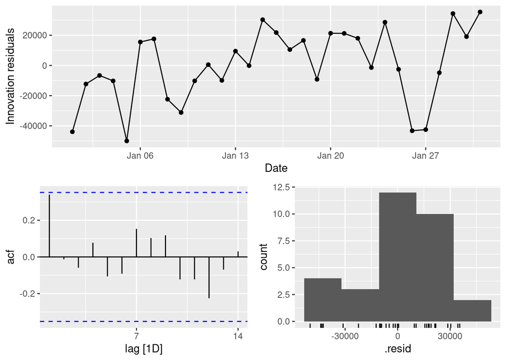

```r
fit |> gg_tsresiduals()
```

The residuals from this section of the data do not show a clear pattern, suggesting the model may be adequate. There is no clear evidence of outliers or influential observations.

### Problem 1c

Use the model to forecast the electricity demand that you would expect for the next day if the maximum temperature was $15^\circ\text{C}$ and compare it with the forecast if the with maximum temperature was $35^\circ\text{C}$. Do you believe these forecasts?

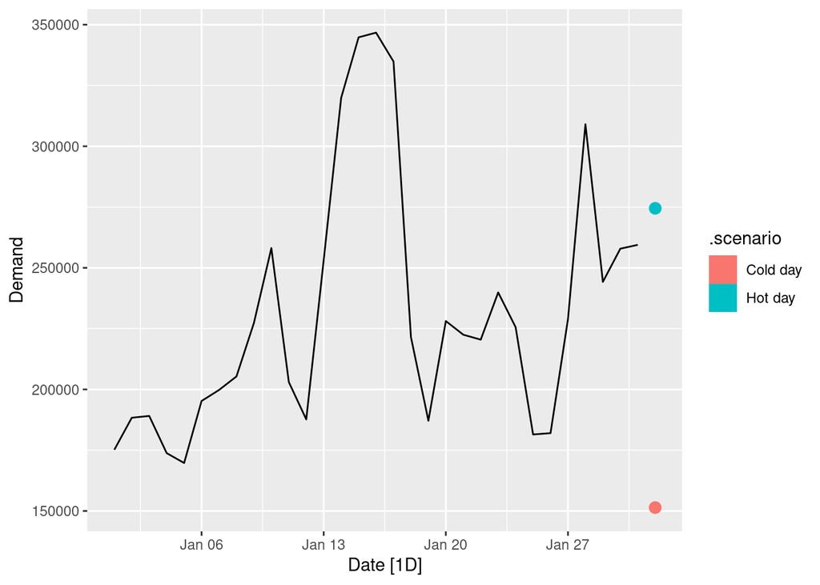

```r
next_day <- scenarios(
  `Cold day` = new_data(jan_vic_elec, 1) |> mutate(Temperature = 15),
  `Hot day` =  new_data(jan_vic_elec, 1) |> mutate(Temperature = 35)
)

fc <- fit |>
  forecast(new_data = next_day)

autoplot(jan_vic_elec, Demand) +
  autolayer(fc)
```

### Problem 1d

Give prediction intervals for your forecasts.

```r
fc |>
  hilo() |>
  select(-.model, -.mean, -Demand, -Temperature)
```

| .scenario | Date | 80% | 95% |
| --- | --- | --- | --- |
| Cold day | 2014-02-01 |  |  |
| Hot day | 2014-02-01 |  |  |

### Problem 1e

Plot Demand vs Temperature for all of the available data in `vic_elec` aggregated to daily total demand and maximum temperature. What does this say about your model?

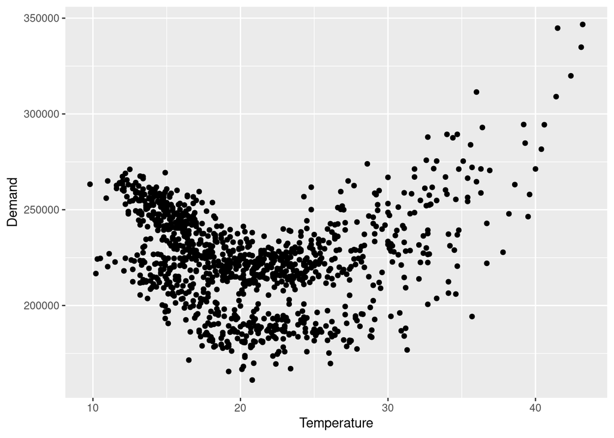

```r
vic_elec |>
  index_by(Date = as_date(Time)) |>
  summarise(Demand = sum(Demand), Temperature = max(Temperature)) |>
  ggplot(aes(x = Temperature, y = Demand)) +
  geom_point()
```

The “U” shaped scatterplot suggests that there is a non-linear relationship between electricity demand and daily maximum temperature. The model assumption that electricity demand is linearly predicted by temperature is incorrect.

# Problem 2 [optional, ungraded]

Data set `olympic_running` contains the winning times (in seconds) in each Olympic Games sprint, middle-distance and long-distance track events from 1896 to 2016.

1. Plot the winning time against the year. Describe the main features of the plot.
2. Fit a regression line to the data. Obviously the winning times have been decreasing, but at what *average* rate per year?
3. Plot the residuals against the year. What does this indicate about the suitability of the fitted line?
4. Predict the winning time for each race in the 2020 Olympics. Give a prediction interval for your forecasts. What assumptions have you made in these calculations?

# Problem 2 Solutions

### Problem 2a

Plot the winning time against the year. Describe the main features of the plot.

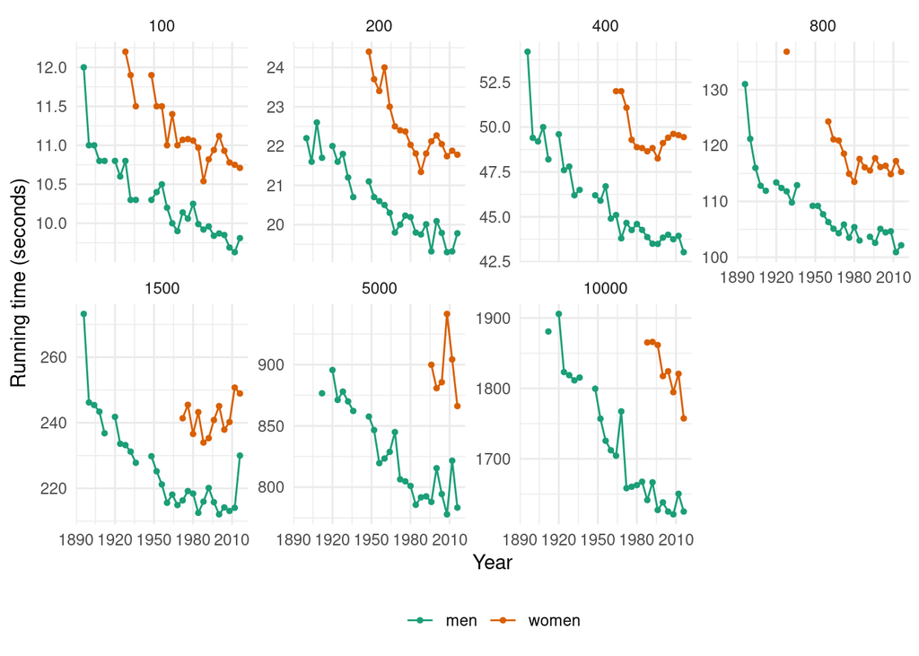

```r
olympic_running |>
  ggplot(aes(x = Year, y = Time, colour = Sex)) +
  geom_line() +
  geom_point(size = 1) +
  facet_wrap(~Length, scales = "free_y", nrow = 2) +
  theme_minimal() +
  scale_color_brewer(palette = "Dark2") +
  theme(legend.position = "bottom", legend.title = element_blank()) +
  labs(y = "Running time (seconds)")
```

The running times are generally decreasing as time progresses (although the rate of this decline is slowing down in recent olympics). There are some missing values in the data corresponding to the World Wars (in which the Olympic Games were not held).

### Problem 2b

Fit a regression line to the data. Obviously the winning times have been decreasing, but at what *average* rate per year?

```r
fit <- olympic_running |>
  model(TSLM(Time ~ trend()))
tidy(fit)
```

| Length | Sex | .model | term | estimate | std.error | statistic | p.value |
| --- | --- | --- | --- | --- | --- | --- | --- |
| 100 | men | TSLM(Time ~ trend()) | (Intercept) | 11.14889598 | 9.089530e-02 | 122.656465 | 1.860287e-37 |
| 100 | men | TSLM(Time ~ trend()) | trend() | -0.05044965 | 4.793695e-03 | -10.524168 | 7.240317e-11 |
| 100 | women | TSLM(Time ~ trend()) | (Intercept) | 12.35009274 | 1.625933e-01 | 75.956960 | 4.584668e-25 |
| 100 | women | TSLM(Time ~ trend()) | trend() | -0.05674011 | 7.488876e-03 | -7.576586 | 3.722557e-07 |
| 200 | men | TSLM(Time ~ trend()) | (Intercept) | 22.30217116 | 1.399479e-01 | 159.360527 | 4.057101e-39 |
| 200 | men | TSLM(Time ~ trend()) | trend() | -0.09952289 | 7.248027e-03 | -13.731032 | 3.795639e-13 |
| 200 | women | TSLM(Time ~ trend()) | (Intercept) | 25.50471276 | 5.250495e-01 | 48.575829 | 8.339876e-19 |
| 200 | women | TSLM(Time ~ trend()) | trend() | -0.13453044 | 2.273886e-02 | -5.916323 | 2.170598e-05 |
| 400 | men | TSLM(Time ~ trend()) | (Intercept) | 50.30776256 | 4.448092e-01 | 113.099642 | 1.527163e-36 |
| 400 | men | TSLM(Time ~ trend()) | trend() | -0.25829538 | 2.345864e-02 | -11.010674 | 2.752408e-11 |

[output cut: 18 more lines]

### Problem 2c

Plot the residuals against the year. What does this indicate about the suitability of the fitted line?

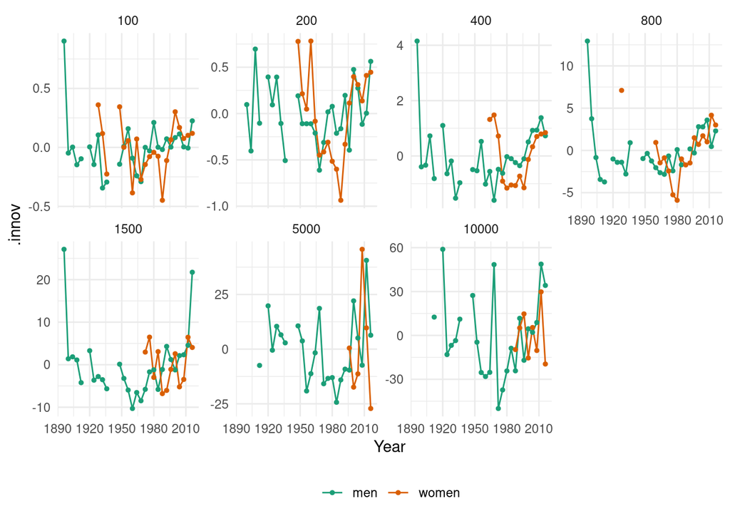

```r
augment(fit) |>
  ggplot(aes(x = Year, y = .innov, colour = Sex)) +
  geom_line() +
  geom_point(size = 1) +
  facet_wrap(~Length, scales = "free_y", nrow = 2) +
  theme_minimal() +
  scale_color_brewer(palette = "Dark2") +
  theme(legend.position = "bottom", legend.title = element_blank())
```

It doesn’t seem that the linear trend is appropriate for this data.

### Problem 2d

Predict the winning time for each race in the 2020 Olympics. Give a prediction interval for your forecasts. What assumptions have you made in these calculations?

```r
fit |>
  forecast(h = 1) |>
  mutate(PI = hilo(Time, 95)) |>
  select(-.model)
```

| Length | Sex | Year | Time | .mean | PI |
| --- | --- | --- | --- | --- | --- |
| 100 | men | 2020 |  | 9.534507 |  |
| 100 | women | 2020 |  | 10.534409 |  |
| 200 | men | 2020 |  | 19.117439 |  |
| 200 | women | 2020 |  | 21.199739 |  |
| 400 | men | 2020 |  | 42.042310 |  |
| 400 | women | 2020 |  | 48.436264 |  |
| 800 | men | 2020 |  | 99.237699 |  |
| 800 | women | 2020 |  | 111.483433 |  |
| 1500 | men | 2020 |  | 206.998282 |  |
| 1500 | women | 2020 |  | 245.456515 |  |

[output cut: 4 more lines]

Using a linear trend we assume that winning times will decrease in a linear fashion which is unrealistic for running times. As we saw from the residual plots above there are mainly large positive residuals for the last few years, indicating that the decreases in the winning times are not linear. We also assume that the residuals are normally distributed.

# Problem 3 [optional, ungraded]

The annual population of Afghanistan is available in the `global_economy` data set.

1. Plot the data and comment on its features. Can you observe the effect of the Soviet-Afghan war?
2. Fit a linear trend model and compare this to a piecewise linear trend model with knots at 1980 and 1989.
3. Generate forecasts from these two models for the five years after the end of the data, and comment on the results.

# Problem 3 Solutions

### Problem 3a

Plot the data and comment on its features. Can you observe the effect of the Soviet-Afghan war?

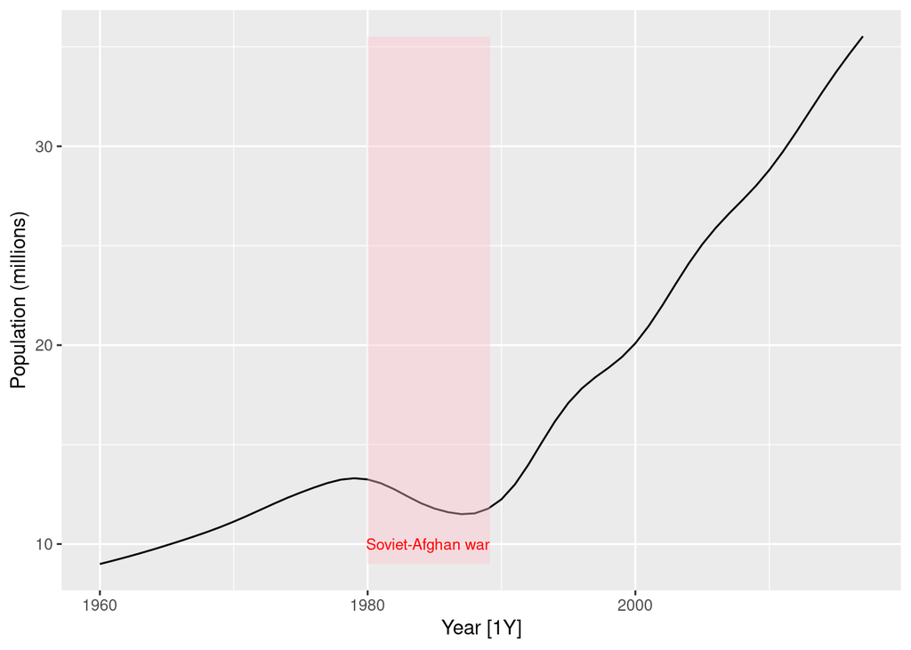

```r
global_economy |>
  filter(Country == "Afghanistan") |>
  autoplot(Population / 1e6) +
  labs(y = "Population (millions)") +
  geom_ribbon(aes(xmin = 1979.98, xmax = 1989.13), fill = "pink", alpha = 0.4) +
  annotate("text", x = 1984.5, y = 10, label = "Soviet-Afghan war", col = "red", size = 3)
```

The population increases slowly from 1960 to 1980, then decreases during the Soviet-Afghan war (24 Dec 1979 – 15 Feb 1989), and has increased relatively rapidly since then. The last 30 years has shown an almost linear increase in population.

### Problem 3b

Fit a linear trend model and compare this to a piecewise linear trend model with knots at 1980 and 1989.

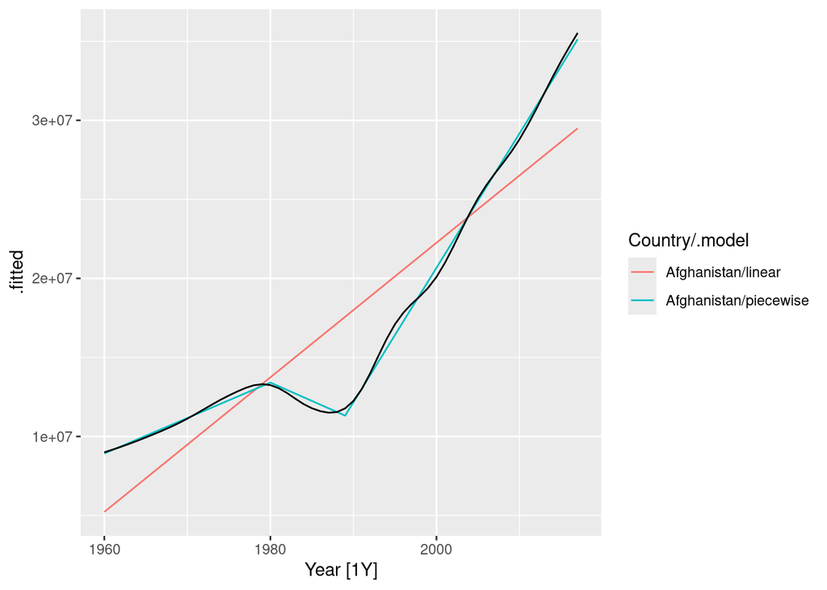

```r
fit <- global_economy |>
  filter(Country == "Afghanistan") |>
  model(
    linear = TSLM(Population ~ trend()),
    piecewise = TSLM(Population ~ trend(knots = c(1980, 1989)))
  )
augment(fit) |>
  autoplot(.fitted) +
  geom_line(aes(y = Population), colour = "black")
```

The fitted values show that the piecewise linear model has tracked the data very closely, while the linear model is inaccurate.

### Problem 3c

Generate forecasts from these two models for the five years after the end of the data, and comment on the results.

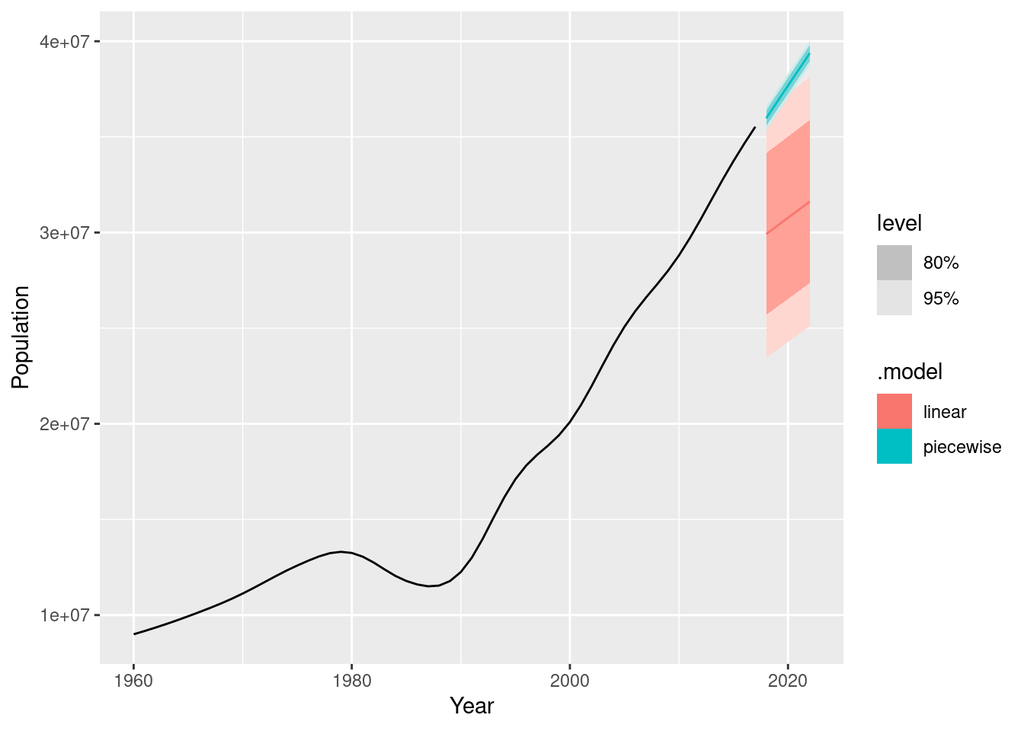

```r
fc <- fit |> forecast(h = "5 years")
autoplot(fc) +
  autolayer(filter(global_economy |> filter(Country == "Afghanistan")), Population)
```

The linear model is clearly incorrect with prediction intervals too wide, and the point forecasts too low.

The piecewise linear model looks good, but the prediction intervals are probably too narrow. This model assumes that the trend since the last knot will continue unchanged, which is unrealistic.